# EIS 2026 Variable Atlas

Every substantive variable in the BPC Election Information Survey, 2026 field, weighted.

3,144 registered voters, weighted by the delivered Morning Consult weight (see 'eis_2026_06_design_data.R' for why this weight rather than a raked one). Bars show a weighted percentage with a 95% confidence interval (`survey::svyciprop` / `svymean`). A branching item's caption states its base condition and the respondent count within that base. Generated by eis_2026_07_plots_overview.R on September 18, 2026.

## Ordinal items (53)

### Age, four bands

n = 3,144 — Weighted mean 2.62 (95% CI 2.57-2.67) on a 1-4 scale

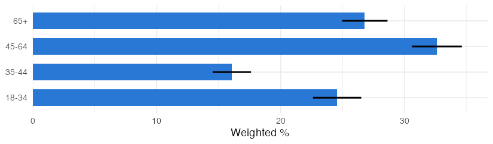

### Confidence could tell whether election content was AI-generated

n = 2,771 — Weighted mean 2.56 (95% CI 2.52-2.61) on a 1-4 scale

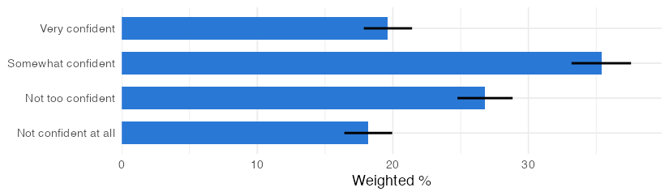

### Whether a given use of AI in elections is a good or a bad thing: Political campaigns using AI to create content, including advertisements for voters, with clear disclosure that AI was used in the process

Base: All respondents (items 4 and 5 are a hidden 50/50 split) — n = 2,928 — Weighted mean 2.74 (95% CI 2.68-2.80) on a 1-5 scale

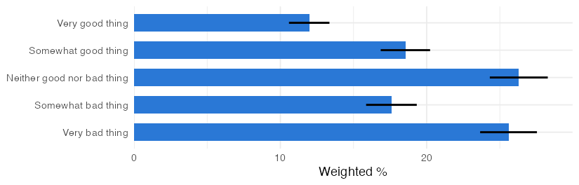

### Whether a given use of AI in elections is a good or a bad thing: Political campaigns using AI to create content, including advertisements for voters, without disclosing that AI was used in the process

Base: All respondents (items 4 and 5 are a hidden 50/50 split) — n = 2,933 — Weighted mean 2.25 (95% CI 2.19-2.31) on a 1-5 scale

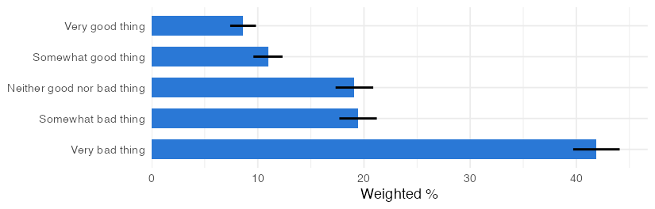

### Whether a given use of AI in elections is a good or a bad thing: Candidates using AI chatbots to answer voters' questions about campaigns

Base: All respondents (items 4 and 5 are a hidden 50/50 split) — n = 2,932 — Weighted mean 2.55 (95% CI 2.49-2.61) on a 1-5 scale

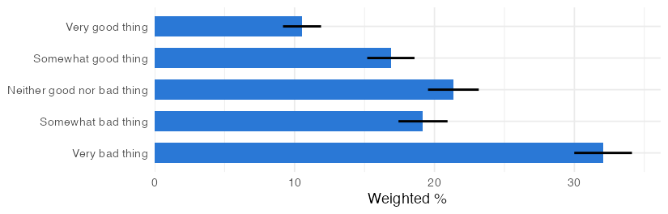

### Whether a given use of AI in elections is a good or a bad thing: Candidates using AI to tailor their political advertisements to individual voters

Base: All respondents (items 4 and 5 are a hidden 50/50 split) — n = 2,917 — Weighted mean 2.49 (95% CI 2.43-2.55) on a 1-5 scale

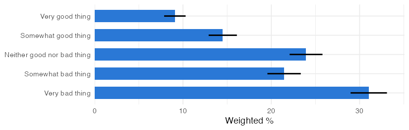

### Whether a given use of AI in elections is a good or a bad thing: Candidates using AI to edit or touch-up photos or videos for their political advertisements

Base: All respondents (items 4 and 5 are a hidden 50/50 split) — n = 2,942 — Weighted mean 2.49 (95% CI 2.44-2.55) on a 1-5 scale

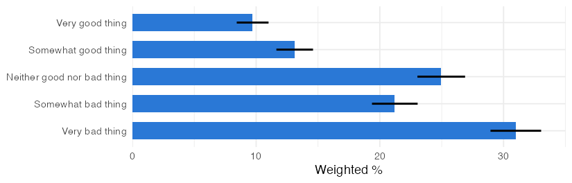

### Whether a given use of AI in elections is a good or a bad thing: Voters using AI chatbots to find out information about a candidate or an issue on the ballot

Base: All respondents (items 4 and 5 are a hidden 50/50 split) — n = 2,928 — Weighted mean 2.83 (95% CI 2.77-2.89) on a 1-5 scale

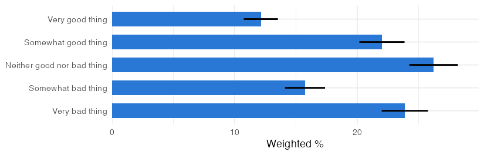

### Whether a given use of AI in elections is a good or a bad thing: Voters using AI chatbots to decide which candidate to vote for

Base: All respondents (items 4 and 5 are a hidden 50/50 split) — n = 1,477 — Weighted mean 2.30 (95% CI 2.22-2.38) on a 1-5 scale

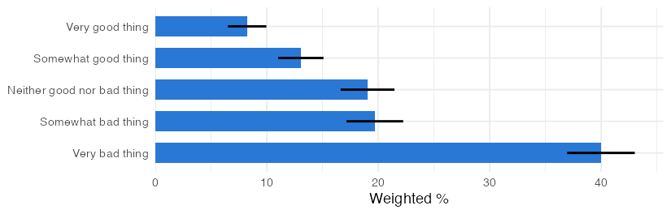

### Whether a given use of AI in elections is a good or a bad thing: Voters using AI chatbots to find information on how to register to vote

Base: All respondents (items 4 and 5 are a hidden 50/50 split) — n = 2,915 — Weighted mean 3.04 (95% CI 2.97-3.10) on a 1-5 scale

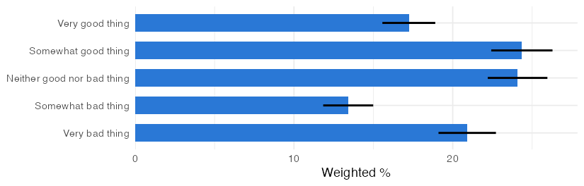

### Whether a given use of AI in elections is a good or a bad thing: Voters using AI chatbots to find out information about how to cast their ballot

Base: All respondents (items 4 and 5 are a hidden 50/50 split) — n = 2,904 — Weighted mean 2.86 (95% CI 2.80-2.92) on a 1-5 scale

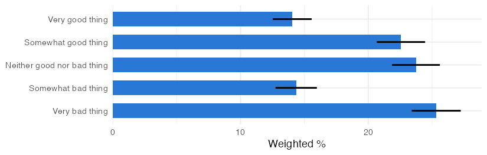

### Whether a given use of AI in elections is a good or a bad thing: Voters using AI chatbots to learn about how candidates' positions align with their personal values and priorities

Base: All respondents (items 4 and 5 are a hidden 50/50 split) — n = 1,448 — Weighted mean 2.89 (95% CI 2.80-2.97) on a 1-5 scale

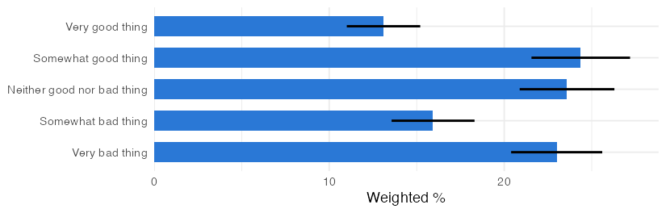

### How much of the election information seen is AI-generated

n = 2,551 — Weighted mean 3.22 (95% CI 3.17-3.27) on a 1-5 scale

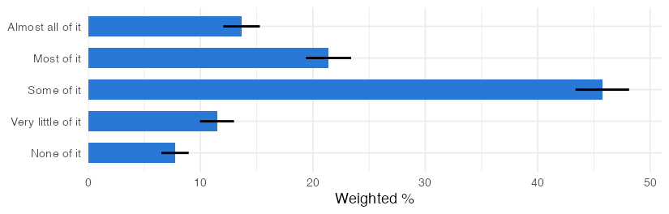

### How frequently uses AI tools such as chatbots

n = 3,144 — Weighted mean 2.19 (95% CI 2.13-2.25) on a 1-5 scale

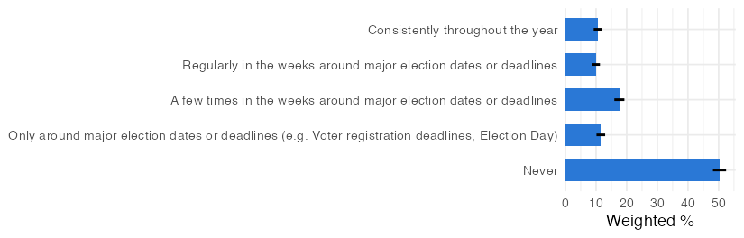

### Level of concern about each possible election problem: Use of AI to spread disinformation or manipulate public opinion

n = 2,886 — Weighted mean 3.12 (95% CI 3.08-3.16) on a 1-4 scale

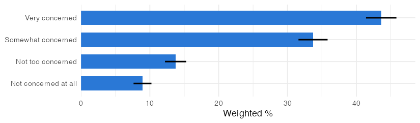

### Level of concern about each possible election problem: Federal or state law enforcement seizing ballots or voting machines

n = 2,856 — Weighted mean 2.69 (95% CI 2.64-2.73) on a 1-4 scale

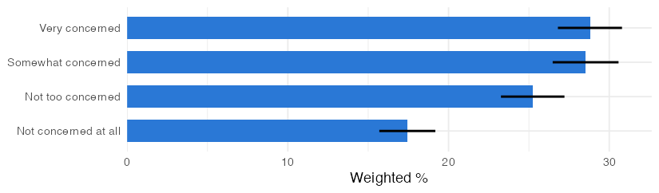

### Level of concern about each possible election problem: Biased or inaccurate counting of ballots

n = 2,881 — Weighted mean 2.84 (95% CI 2.79-2.89) on a 1-4 scale

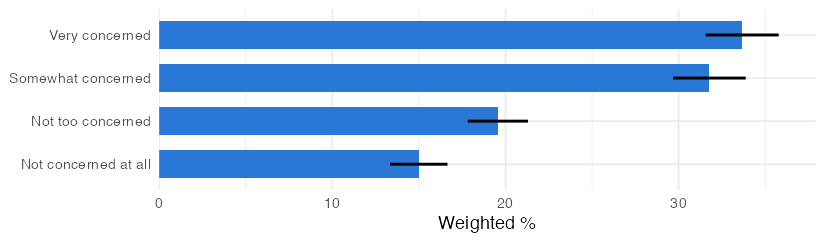

### Level of concern about each possible election problem: Eligible voters being prevented from voting or having valid ballots rejected

n = 2,901 — Weighted mean 2.77 (95% CI 2.72-2.82) on a 1-4 scale

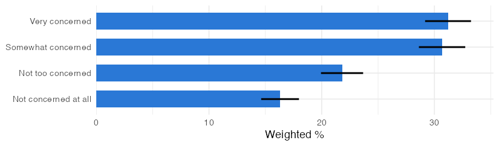

### Level of concern about each possible election problem: Interference from foreign countries or entities

n = 2,856 — Weighted mean 2.78 (95% CI 2.74-2.83) on a 1-4 scale

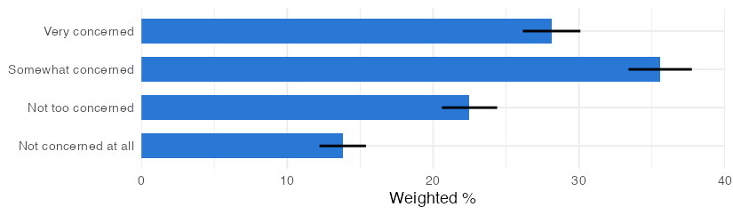

### Level of concern about each possible election problem: Election outcomes being distorted by unfairly drawn districts

n = 2,866 — Weighted mean 2.91 (95% CI 2.86-2.96) on a 1-4 scale

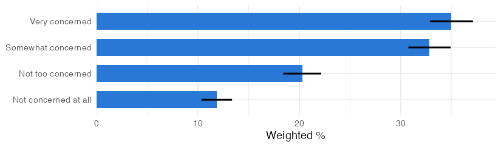

### Level of concern about each possible election problem: Presence of guns, violence, or intimidation at voting locations

n = 2,894 — Weighted mean 2.62 (95% CI 2.57-2.67) on a 1-4 scale

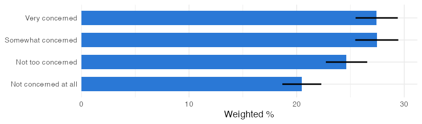

### Level of concern about each possible election problem: Federal law enforcement, such as ICE, being deployed in your community

n = 2,904 — Weighted mean 2.64 (95% CI 2.58-2.69) on a 1-4 scale

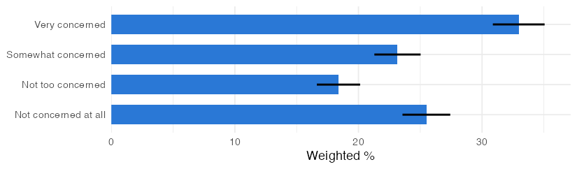

### Level of concern about each possible election problem: Counting ineligible votes (e.g. duplicate, non-citizen, or deceased voters)

n = 2,891 — Weighted mean 2.71 (95% CI 2.67-2.76) on a 1-4 scale

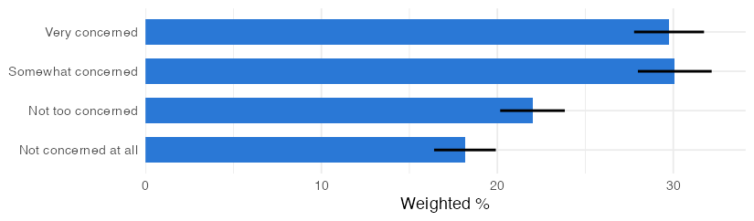

### Level of concern about each possible election problem: Illegal or improper use of mail-in ballots or drop boxes

n = 2,883 — Weighted mean 2.77 (95% CI 2.72-2.81) on a 1-4 scale

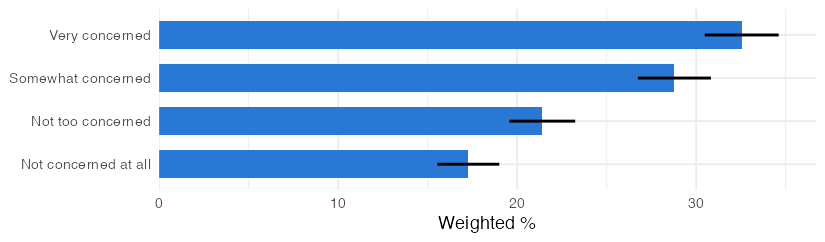

### Level of concern about each possible election problem: Inaccurate or misleading information about elections

n = 2,896 — Weighted mean 2.98 (95% CI 2.94-3.03) on a 1-4 scale

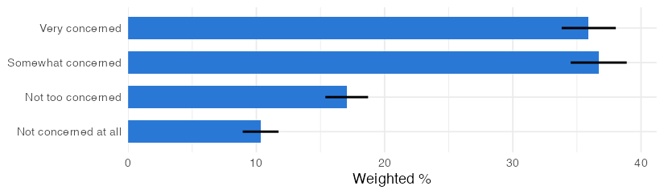

### Level of concern about each possible election problem: Attempts to overturn the results of a fair election

n = 2,883 — Weighted mean 2.93 (95% CI 2.88-2.97) on a 1-4 scale

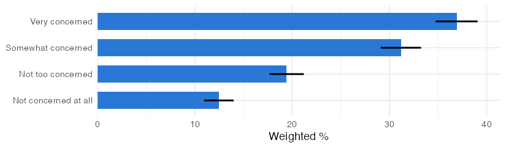

### Level of concern about each possible election problem: Problems at polling places, such as long lines or equipment failures

n = 2,907 — Weighted mean 2.62 (95% CI 2.58-2.67) on a 1-4 scale

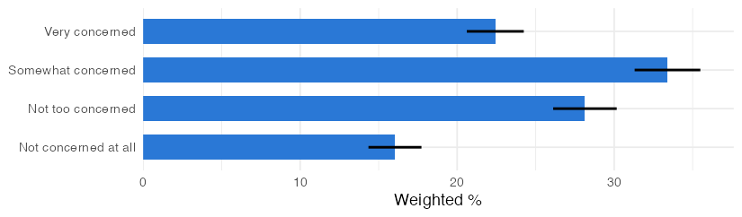

### Level of concern about each possible election problem: Violence or civil unrest after election day

n = 2,887 — Weighted mean 2.74 (95% CI 2.69-2.79) on a 1-4 scale

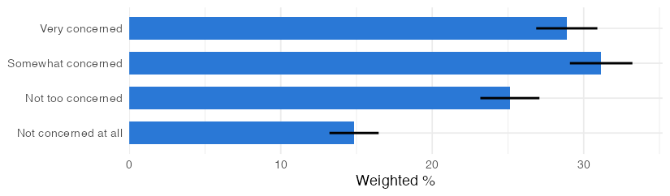